# Reproducible Research: Peer Assessment 1

## Loading and preprocessing the data

Let’s get the data from the zip, and transform the date strings to a Date class.

```r
data <- read.csv(unz("activity.zip", "activity.csv"), stringsAsFactors=F)
data$date <- as.Date(data$date,"%Y-%m-%d")
str(data)
```

```
## 'data.frame':    17568 obs. of  3 variables:
##  $ steps   : int  NA NA NA NA NA NA NA NA NA NA ...
##  $ date    : Date, format: "2012-10-01" "2012-10-01" ...
##  $ interval: int  0 5 10 15 20 25 30 35 40 45 ...
```

## What is mean total number of steps taken per day?

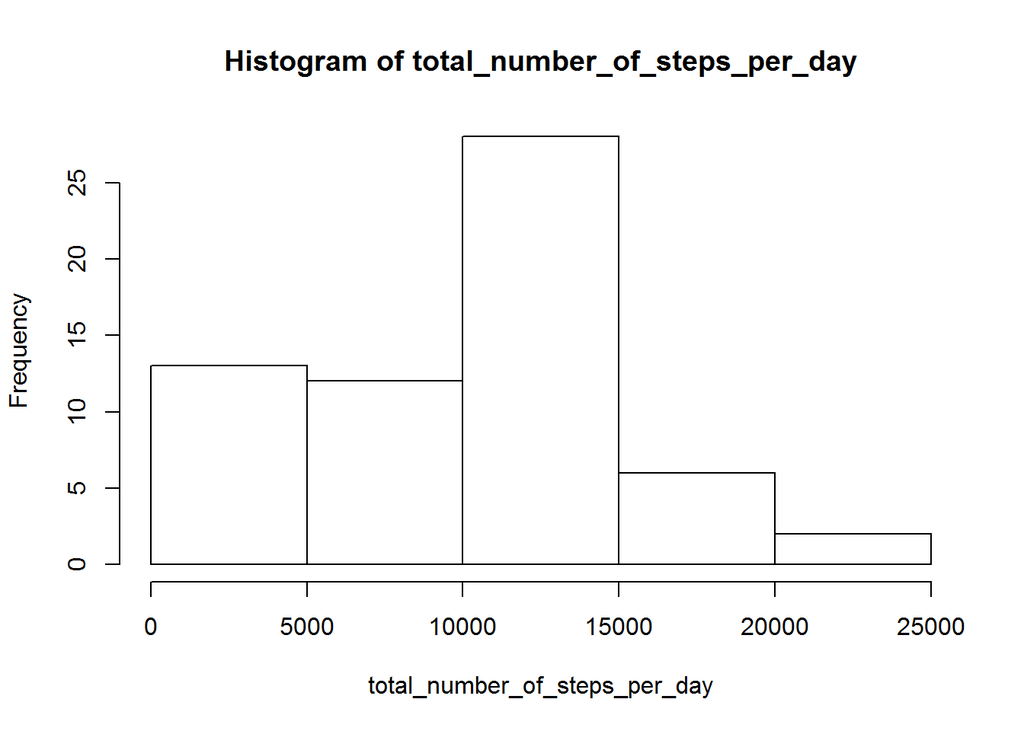

```r
step_measures_per_day <- split(data$steps, data$date)
total_number_of_steps_per_day <- sapply(step_measures_per_day, sum, na.rm=T)
hist(total_number_of_steps_per_day)
```

```r
mean(total_number_of_steps_per_day)
```

```
## [1] 9354
```

```r
median(total_number_of_steps_per_day)
```

```
## [1] 10395
```

The mean total number of steps taken per day is 9354.2295  
The median total number of steps taken per day is 10395

## What is the average daily activity pattern?

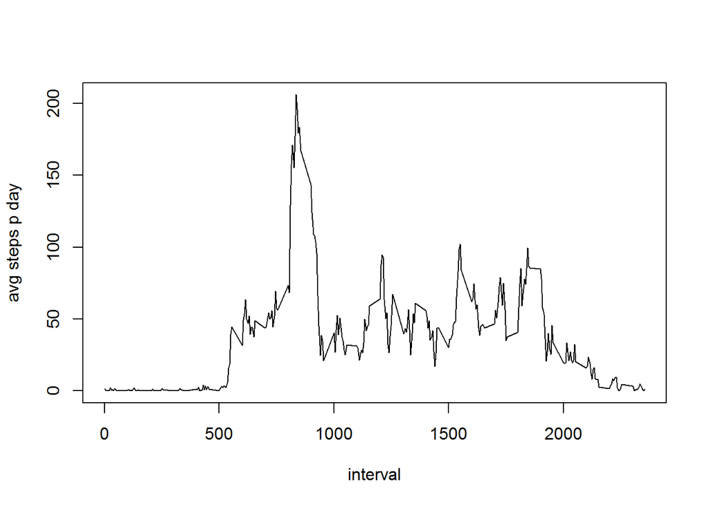

```r
step_sums <- sapply(split(data$steps, data$interval), mean, na.rm=T)
plot(y=step_sums, x=as.numeric(names(step_sums)), type="l", ylab="avg steps p day", xlab="interval")
```

The maximum number (206.1698) of steps per 5 minutes (averaged across all days) occurs at interval 835.

## Imputing missing values

The data contains 2304 missing values (13.1148%).

Instead of ignoring those number of steps, we fill them with the median number of steps for that given interval, across all days.

```r
data_filled <- data
na_steps <- is.na(data_filled$steps)
data_filled$steps[which(na_steps)] <- sapply(which(na_steps),
                                             function(i){
                                               median(
                                                 data_filled$steps[data_filled$interval==data_filled$interval[i]],
                                                 na.rm=T)
                                               }
                                             )
```

Now we can recalculate the number of steps taken per day:

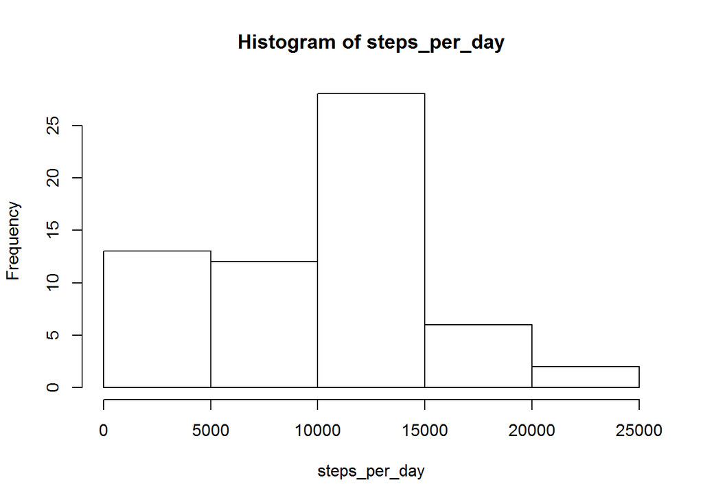

```r
steps_per_day <- sapply(split(data_filled$steps, data_filled$date), sum, na.rm=T)
hist(steps_per_day)
```

```r
mean(steps_per_day)
```

```
## [1] 9504
```

```r
median(steps_per_day)
```

```
## [1] 10395
```

The new mean total number of steps taken per day is 9503.8689  
The new median total number of steps taken per day is 10395

The median steps per day has not changed, as we used exactly that value as replacement for `NA` values.  
The average increased a little bit (149.6393)

## Are there differences in activity patterns between weekdays and weekends?

[figure not shown]

```r
wdays <- unclass(as.POSIXlt(data_filled$date))$wday
data_filled <- cbind(data_filled, weekday=(wdays==0|wdays==6))
data_filled <- cbind(data_filled, weekend=!data_filled$weekday)
weekend_sums <- sapply(split(data_filled$steps[data_filled$weekend], data_filled$interval[data_filled$weekend]), mean, na.rm=T)
week_sums <- sapply(split(data_filled$steps[data_filled$weekday], data_filled$interval[data_filled$weekday]), mean, na.rm=T)
par(mfrow=c(2,1))
ylim=c(min(c(weekend_sums,week_sums)), max(c(weekend_sums,week_sums)))
plot(y=weekend_sums, x=as.numeric(names(weekend_sums)), type="l", main="weekend", xlab="interval", ylab="avg steps p day", ylim=ylim)
plot(y=week_sums, x=as.numeric(names(week_sums)), type="l", main="weekday", xlab="interval", ylab="avg steps p day",ylim=ylim)
```